# Spike-in Controls for cfMeDIP-seq

Wilson et al. (2022) - Technical Highlights

Cell Reports Methods 2(9):100294

January 2026

## Executive Summary

**Publication:** Wilson, S.L., Shen, S.Y., Harmon, L., et al. (2022)  
*Cell Reports Methods* 2(9):100294

**Achievement:** Synthetic spike-in controls enabling **absolute quantification** and **batch effect mitigation** for cfMeDIP-seq

**The Problem**

- No absolute quantification
- Unaccounted technical biases
- Substantial batch effects (~5%)

**The Solution**

- 52 synthetic spike-in controls
- GLM-based calibration
- Batch variance reduced to <1%

> “Sensitive and reproducible cell-free methylome quantification”

# 1. The Problem

## Limitations of cfMeDIP-seq (Pre-2022)

**Three Fundamental Issues:**

1. **Arbitrary Quantification**
   - Read counts not comparable across experiments
   - No absolute units (just “counts”)
   - Cannot combine data from different studies
2. **Technical Biases**
   - Fragment length affects enrichment
   - GC content influences capture
   - CpG density impacts efficiency
   - *No standardized correction method*
3. **Batch Effects**
   - Different labs → different results
   - Reagent lots introduce variation
   - ~5% of total variance from technical factors

## Prior Approaches Were Inadequate

| Method | Approach | Limitations |
| --- | --- | --- |
| **Arabidopsis spike-ins** | Plant DNA controls | Global assessment only; no fragment-specific correction |
| **Input DNA sequencing** | Sequence pre-IP sample | Cannot adjust for IP efficiency variations |
| **Read depth normalization** | Library size scaling | Confounds biological with technical variation |
| **QSEA computational** | Model-based correction | May introduce artifacts; no absolute quantification |

**None provided absolute quantification in defined units**

# 2. Spike-in Design

## Factorial Design Strategy

**Coverage of cfDNA Fragment Properties:**

| Parameter | Values | Rationale |
| --- | --- | --- |
| **Length** | 80 bp, 160 bp, 320 bp | Typical cfDNA size distribution |
| **GC Content** | 35%, 50%, 65% | Low, medium, high GC regions |
| **CpG Fraction** | 1/80, 1/40, 1/20 bp | CpG-poor to CpG-rich |

**Factorial Combinations:** 3 × 3 × 3 = **27 conditions**

**Dual Sequences:** Methylated + Unmethylated for each = **54 total**

**Achieved:** 52 spike-ins (2 synthesis failures)

## Design Constraints & Validation

**Critical Requirements:**

✓ **No human genome alignment**

- BLASTN verified against GRCh38/hg38
- E-value threshold, bit score <50

✓ **No secondary structure**

- UNAFold (80-160 bp)
- RNAstructure (320 bp)
- Prevents synthesis problems & systematic biases

✓ **Sequence generation**

- GenRGenS (Markov model-based)
- Matches target length, GC, CpG parameters

✓ **Methylation verification**

- M.SssI CpG methyltransferase
- Restriction digest confirmation

# 3. Technical Validation

## Experiment 1: Spike-ins Alone

**Design:** cfMeDIP-seq on 9.99 ng spike-in pool (no biological sample)

**Purpose:** Assess inherent biases in isolation

**Key Results:**

| Metric | Input | Output |
| --- | --- | --- |
| **Methylation specificity** | 51% methylated, 49% unmethylated | **97% methylated** |
| **Non-specific binding** | N/A | **3% unmethylated** |

**Observed Biases (Expected & Confirmed):**

- ✓ Fragment length: 160 bp enriched (size selection)
- ✓ GC content: High GC enriched
- ✓ CpG fraction: High CpG enriched, low CpG depleted

**Critical:** Unmethylated signal showed **no systematic bias** (random non-specific binding)

## Experiment 2: HCT116 Optimization

**Design:** 0.01 ng, 0.05 ng, 0.1 ng spike-ins + 10 ng HCT116 genomic DNA

**Sequencing:** NovaSeq 6000, 60M paired-end reads/sample

**Optimal Amount: 0.01 ng**

**Performance:**

[output not shown]

**Reproducibility Test:** Alternative 320 bp sequences (same properties, different sequence) showed ≤4% variation in read counts → sequence-specific effects minimal

## Experiment 3: Multi-Lab Batch Effects

**Design:** 5 AML patient plasma samples (10 ng each) + 0.01 ng spike-ins → 3 independent labs

**Intentional Variations Introduced:**

| Variable | Lab A | Lab B | Lab C |
| --- | --- | --- | --- |
| **Adapter** | xGen Stubby | Custom (2 bp UMI) | xGen Stubby |
| **Ligation** | 4°C, 16h | 4°C, 16h | 20°C, 2h |
| **Antibody** | Lot RD004 | Lot RD001 | Lot RD004 |
| **Filler DNA** | 50% meth + 50% unmeth | 50% meth + 50% unmeth | **100% unmeth** ⚠ |
| **PCR Cycles** | 13-15 | 13 | 11 |
| **Sequencer** | NovaSeq (100 bp PE) | NovaSeq (100 bp PE) | NextSeq (75 bp PE) |
| **Read Depth** | 60M | 100M | 85M |

**Critical Finding:** Spike-in normalization successfully corrected Lab C’s protocol deviation (unmethylated filler)

# 4. GLM Quantification Model

## Mathematical Framework

**Generalized Linear Model (Gaussian GLM):**

$$\eta = \beta_0 + \beta_{reads} \cdot
x_{reads} + \beta_{len} \cdot x_{len} + \beta_{GC} \cdot x_{GC} +
\beta_{CpG} \cdot (x_{CpG})^{1/3}$$

**Features:**

- $x_{reads}$: Deduplicated read count (UMI-collapsed)
- $x_{len}$: Fragment length (bp)
- $x_{GC}$: GC content (proportion)
- $x_{CpG}$: CpG fraction (cube root transformed)

**Output:** Absolute molar amount ($\eta$) in **picomoles**

## Window-Based Quantification

**Genomic Binning:** 300 bp windows across genome

**Overlap Adjustment:** For fragments partially overlapping windows:

$$\eta' =
\left(\frac{\ell}{\ell^*}\right) \times \eta$$

Where:

- $\ell$ = length of overlap between fragment and window
- $\ell^*$ = 300 bp (window size)
- $\eta'$ = adjusted molar amount

**Implementation:** Ensures accurate quantification when fragments span window boundaries

## Model Performance

**Training/Testing Framework:**

- Held-out spike-ins for validation
- Varied training set size: 6 to 25 spike-ins
- 100 random iterations per size

**Results:**

| Metric | Value |
| --- | --- |
| **Mean absolute error** | ≤0.002 pmol |
| **Model R²** | **0.93** |
| **Bland-Altman agreement** | 95% within narrow CI |

**Key Finding:** Performance improved with more training spike-ins; larger training sets showed greater variance (due to smaller test sets)

# 5. Biological Validation

## Correlation with EPIC Array

**Comparison:** cfMeDIP-seq molar amounts vs. Illumina EPIC array M-values (HCT116)

**Filtering:** 4,446,375 genomic windows after removing:

- Simple repeats
- ENCODE blacklist
- Low mappability (≤0.5)
- High variance windows (SD ≥0.05 pmol)

**Results:**

| CpG Probes/Window | Molar Amount (r) | Read Count (r) |
| --- | --- | --- |
| ≥3 probes | 0.62 | 0.61 |
| ≥5 probes | **0.82** | 0.80 |
| ≥7 probes | 0.87 | 0.85 |
| ≥10 probes | 0.90 | 0.89 |

## Validation Insights

**Why Correlation Improves with More Probes?**

- More array probes → better representation of true methylation
- Windows with single probes may not capture regional methylation

**Molar Amounts vs Read Counts:**

- Similar correlation (slight advantage for molar amounts)
- **Key benefit:** Absolute quantification enables cross-experiment comparison

**Why M-values?**

- β-values have heteroscedasticity (variance depends on mean)
- M-values (log2 ratio) provide homoscedastic measurement

> Validation against orthogonal platform confirms biological accuracy

# 6. Batch Effect Mitigation

## Principal Component Analysis

**Four Normalization Approaches Compared:**

1. Raw read counts (no normalization)
2. QSEA normalization (current standard)
3. Spike-in molar amounts (no filtering)
4. **Spike-in + filtering** (recommended)

**Data:** 5 AML samples × 3 labs = 15 technical replicates

## PC1: Biological vs Technical Signals

| Method | PC1 Variance | Associated Variables | Cohen’s d |
| --- | --- | --- | --- |
| **Raw counts** | 80% | Batch (non-sig), Filler (non-sig) | Small |
| **QSEA** | 81% | **Filler (significant)** ⚠ | Artifact |
| **Spike-in only** | 78% | Batch (non-sig) | Small |
| **Spike-in + filter** | 83% | **Sample (biological), Sex (biological)** ✓ | Biological |

**Critical Observation:**

- QSEA **introduced spurious correlation** with filler DNA type
- Spike-in + filtering: Biological signals dominate PC1
- Technical factors relegated to minor components

## Variance Reduction Achievement

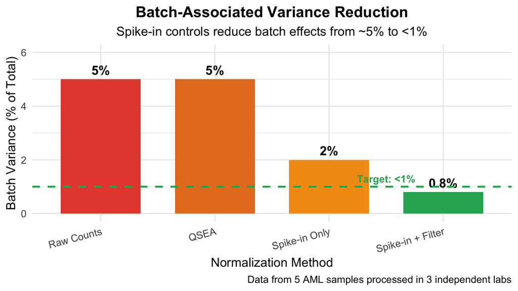

## Repetitive Elements Finding

**Interpretation:**

- Batch effects particularly affect repetitive regions
- May require special handling in downstream analysis
- Spike-in normalization identifies these problematic regions

# 7. Quality Control

## Methylation Specificity Metric

**Calculation:**

$$\text{Methylation Specificity} =
\frac{\text{Methylated Spike-in Reads}}{\text{Total Spike-in
Reads}}$$

**Thresholds:**

| Range | Status | Action |
| --- | --- | --- |
| **≥0.98** | Pass ✓ | Proceed with analysis |
| 0.95-0.98 | Warning ⚠ | Investigate, may use with caution |
| **<0.95** | Fail ✗ | Remove sample (poor cfMeDIP performance) |

**Implementation:** `methylation_specificity()` function in spiky package

## Recommended Filtering Pipeline

**Remove Four Categories:**

1. **Simple repeats** → 1,070,387 regions removed
   - UCSC simple repeats track
2. **ENCODE blacklist** → 239,461 regions removed
   - Known problematic genomic regions
3. **Low mappability** → 549,876 regions removed
   - Umap k100 multi-read score ≤0.5
4. **High variance** → 906 regions removed
   - SD of molar amount ≥0.05 pmol between replicates

## High Molar Amount Regions

**Investigation of Outliers:** 11 windows with ≥0.25 pmol

**Top 4 Windows (≥0.70 pmol):**

| Gene | Context | Significance |
| --- | --- | --- |
| *MIER2* (2 windows) | Tumor suppressor | Altered in colorectal cancer |
| *HCN2* | Ion channel | Tissue-specific expression |
| *RNF126* | E3 ubiquitin ligase | Cancer-relevant |

**Alu Elements:** 6/7 windows with mappability <1 overlapped Alu repeats

> Highest methylation signals overlap cancer-relevant genes in HCT116 cells

# 8. The spiky Package

## Bioconductor Package Overview

**Repository:**

- Bioconductor: `https://bioconductor.org/packages/spiky`
- GitHub: `https://github.com/trichelab/spiky`

**Purpose:** End-to-end cfMeDIP-seq analysis with spike-in controls

**Requirements:**

- R version ≥3.6 (≥4.0 recommended)
- Dependencies: GenomicRanges, SummarizedExperiment, stats

## Core Functions

**1. methylation_specificity()**

```r
# Calculate methylation specificity from spike-in coverage
ms <- methylation_specificity(spike_coverage)
# Returns: mean and median values
# Flags: poor-quality samples
```

**2. model_glm_pmol()**

```r
# Build GLM on methylated spike-ins
model <- model_glm_pmol(spike_data)
# Generates: batch-specific coefficients
# Creates: Bland-Altman diagnostic plot
# Returns: trained model object
```

**3. Prediction Pipeline**

```r
# Apply model to biological samples
molar_amounts <- predict(model, sample_data)
# Predicts: molar amount per genomic window
# Adjusts: fragment overlap with windows
# Outputs: absolute quantification (picomoles)
```

## Workflow Integration

**Input:** Coverage objects from aligned cfMeDIP-seq BAM files

**Process:**

1. Load spike-in coverage data
2. Calculate methylation specificity → **QC check**
3. Train GLM on spike-in data → **Calibration**
4. Predict molar amounts for biological samples → **Quantification**
5. Apply filtering recommendations → **Clean data**
6. Output quantified methylation data → **Analysis-ready**

**Integration:** Compatible with MEDIPIPE pipeline (Zeng et al. 2023)

# 9. Data & Resources

## Published Data

**GEO Accession GSE166259:** (Public) - Raw HCT116 cell line data - Processed AML patient data

**EGA Accession EGAS00001005069:** (Controlled Access)

- Raw AML patient data
- Access: University Health Network Genomics Data Access Committee

**Zenodo Deposits:**

- Analysis code: `10.5281/zenodo.4683791`
- spiky package: `10.18129/B9.bioc.spiky`

**Table S1:** Complete sequences of all 52 spike-in fragments

- Sequence ID, length, GC, CpG fraction
- Methylation status
- Restriction enzymes for verification

## Commercial & IP Considerations

**Patent:** PCT/CA2020/051507

**Inventors:** Wilson, Shen, Triche, De Carvalho, Hoffman

**License:** Licensed to **Adela, Inc.**

**Conflicts of Interest:**

- Shen, Bratman, De Carvalho: Leadership roles & equity in Adela
- Multiple authors: Inventors on related cfDNA methylation patents

**Research Use:** Open-source spiky package available

> Foundation for Adela’s MCED and MRD commercial platforms

# 10. Key Innovations

## Methodological Advances

**1. First Synthetic Spike-ins for Enrichment Methylation Methods**

- Prior art: RNA-seq, ChIP-seq, bisulfite methods
- Novel: MeDIP-seq and cfMeDIP-seq application

**2. Comprehensive Factorial Design**

- Systematically covers parameter space
- Enables simultaneous correction for length, GC, CpG biases

**3. Absolute Quantification**

- Converts arbitrary counts to picomoles
- Enables true quantitative cross-experiment comparisons

**4. Batch Effect Mitigation**

- Reduces batch variance: **5% → <1%**
- Preserves biological signals

## Impact Metrics

[figure not shown]

# 11. Limitations & Future

## Acknowledged Limitations

**1. Limited Parameter Coverage**

- Only 3 values per parameter (length, GC, CpG)
- Future: More granular coverage could improve modeling

**2. Binary Methylation Assessment**

- Spike-ins fully methylated or unmethylated
- Cannot distinguish methylation status of individual biological fragments post-IP
- Know ~97% methylated, but not which specific fragments

**3. Partial CpG Coverage**

- 320 bp, 65% GC failed (secondary structure)
- Missing one combination from full factorial

**4. Platform Specificity**

- Designed for Illumina paired-end sequencing
- May require redesign for PacBio, Oxford Nanopore

## Future Opportunities

**Technical Improvements:**

- Expanded spike-in libraries (more parameter values)
- Long-read sequencing adaptation
- Single-cell cfMeDIP-seq compatibility
- Ultra-low input optimization (<1 ng)

**Application Extensions:**

- Other enrichment methods (MBD-seq, MethylCap-seq)
- Histone modification ChIP-seq
- Other sample types (urine, CSF, saliva)

**Clinical Translation:**

- FDA submissions with validated QC
- Multi-center clinical trials
- Reference materials for proficiency testing

# 12. Impact on Field

## Immediate Applications

**Clinical Assay Development:**

- Enables regulatory submissions (absolute quantification)
- Provides standardized QC metrics
- Facilitates multi-center studies

**Research Studies:**

- Meta-analyses now possible (common units)
- Improved statistical power (variance reduction)
- Better detection of small biological effects

**Technology Development:**

- Foundation for assay optimization
- Systematic protocol comparison
- Quantifies impact of reagent changes

## Adoption by Adela

**Commercial Integration:**

- Licensed technology to Adela, Inc.
- Incorporated into MRD and MCED platforms
- Integrated with MEDIPIPE pipeline (Zeng et al. 2023)

**Evidence:**

- Patent licensing agreement
- Co-authors’ involvement with Adela
- Foundation for clinical validation studies

> Key differentiator: Adela’s absolute quantification capability

## Broader Implications

**For Enrichment-Based Methods:**

- Design principles applicable to other MeDIP-seq variants
- Template for histone ChIP-seq spike-ins
- Framework for other enrichment assays

**For cfDNA Field:**

- Demonstrates importance of technical standardization
- Model for rigorous validation studies
- Raises bar for commercial assay development

**For Regulatory Science:**

- Provides standardized QC framework
- Enables cross-laboratory comparisons
- Supports clinical translation pathway

# 13. Cost-Benefit Analysis

## Implementation Costs

**One-Time Investment:**

| Item | Cost |
| --- | --- |
| Spike-in synthesis (52 fragments) | $2,000-3,000 |
| Methylation reagents | $200 |
| Validation testing | $500-1,000 |
| **Total initial** | **~$3,000-4,000** |

**Per-Sample Costs:**

| Item | Cost |
| --- | --- |
| Spike-in DNA (0.01 ng) | $0.10-0.50 |
| Additional sequencing | Negligible (<1% reads) |
| Computational | Minimal (automated) |
| **Total per sample** | **~$1-2** |

## Return on Investment

**Quantitative Benefits:**

- Batch variance: 5% → <1% (5× improvement)
- Technical replicate agreement: 10/10 improved
- Cross-study comparability: Enabled

**Qualitative Benefits:**

- Regulatory compliance pathway
- Reduced need for repeat experiments
- Meta-analysis capability
- Multi-center study feasibility

**ROI Assessment:**

> $1-2 per sample investment is negligible compared to: - Clinical trial costs ($10K-100K per patient) - Failed experiments from batch effects - Regulatory submission requirements

# 14. Critical Assessment

## Strengths

**Experimental Design:**

1. Systematic factorial approach
2. Multiple validation experiments
3. Appropriate controls (unmethylated spike-ins)
4. Biological validation (EPIC array)

**Statistical Rigor:**

5. Held-out validation
6. 100 random iterations for robustness
7. Effect size reporting (Cohen’s d)
8. Multiple testing correction
9. Diagnostic plots (Bland-Altman)

**Open Science:**

10. Complete data deposition (GEO, EGA)
11. Open-source software (Bioconductor)
12. Reproducible code (Zenodo/GitHub)

## Areas for Development

**Technical Limitations:**

1. Platform specificity (Illumina-focused)
2. Limited to short-read sequencing
3. Binary methylation (no partial methylation)
4. Validation primarily in blood cancer (AML)

**Future Validation Needed:**

5. Low-shedding solid tumors (early stage)
6. Ultra-low input samples (<10 ng)
7. Non-plasma cfDNA sources
8. Long-read sequencing platforms
9. Clinical utility in prospective trials

> Strong foundation; opportunities for extension

# 15. Connection to Adela vs GRAIL

## Platform Differentiator

**Adela (cfMeDIP-seq):**

- ✓ Uses Wilson et al. 2022 spike-in technology
- ✓ Absolute quantification (picomoles)
- ✓ Genome-wide bias correction
- ✓ Batch effect resistance (<1% variance)
- ✓ No bisulfite conversion (DNA preservation)

**GRAIL (Targeted Bisulfite):**

- Targeted sequencing (~1M CpG sites)
- No published spike-in controls
- Read count-based quantification
- Bisulfite conversion required
- Deep sequencing of selected regions

> Spike-in normalization is a key technical differentiator

## Quantification Comparison

| Feature | Adela (with spike-ins) | GRAIL |
| --- | --- | --- |
| **Units** | Picomoles (absolute) | Read counts (relative) |
| **Cross-experiment comparison** | Yes (common units) | Limited (batch effects) |
| **Bias correction** | Length, GC, CpG | Computational models |
| **Batch variance** | <1% of total | Not reported |
| **QC metrics** | Methylation specificity | Standard sequencing QC |
| **Validation** | Multi-lab (Wilson 2022) | CCGA study (15,000 participants) |

**Note:** GRAIL has extensive clinical validation; Adela has superior technical normalization

# 16. Integration with MEDIPIPE

## MEDIPIPE Pipeline

**MEDIPIPE** (Zeng et al. 2023): Automated cfMeDIP-seq analysis

**Spike-in Integration Points:**

**Stage 1: Alignment**

- FASTQ → BAM (spike-in sequences + human genome)
- UMI-based deduplication

**Stage 2: Spike-in Analysis**

- Calculate methylation specificity (QC)
- Train GLM model (calibration)
- Generate diagnostic plots

**Stage 3: Quantification**

- Apply GLM to biological samples
- Window-based molar amount calculation
- Generate normalized matrices

**Stage 4: Quality Filtering**

- Apply Wilson et al. 2022 filters
- Output analysis-ready data

# Conclusions

## Key Achievements

Wilson et al. (2022) represents a **landmark advance** for cfMeDIP-seq:

1. **Absolute Quantification**
   - Picomolar units enable cross-study comparisons
   - Foundation for regulatory submissions
2. **Bias Correction**
   - Adjusts for fragment-specific properties
   - Genome-wide applicability
3. **Batch Effect Mitigation**
   - Reduces technical variance: **5% → <1%**
   - Preserves biological signals
4. **Clinical Translation**
   - Licensed to Adela for commercial use
   - Integrated into MEDIPIPE pipeline
   - Enables multi-center validation studies

## Technical Excellence

**Rigorous Methodology:**

- Factorial design with systematic validation
- Held-out testing, effect sizes, diagnostic plots
- Complete data and code sharing

**Practical Implementation:**

- Open-source spiky R package
- Detailed protocols and methods
- Minimal per-sample cost (~$1-2)

**Immediate Impact:**

- 10/10 technical replicates improved
- Correlation with arrays: r = 0.82
- Multi-lab reproducibility demonstrated

> Sets new standard for enrichment-based methylation methods

## Future Outlook

**Near-Term:**

- Adoption in clinical trials (CAMPERR, etc.)
- Regulatory submissions (FDA, international)
- Multi-center validation studies

**Mid-Term:**

- Extension to other sample types
- Long-read sequencing adaptation
- Integration with multi-omics platforms

**Long-Term:**

- Population screening programs
- Standard-of-care integration
- Precision medicine applications

> From methodological innovation to clinical standard

## Questions?

### Key Resources

**Publication:** Wilson et al. (2022) *Cell Rep Methods* 2(9):100294

DOI: 10.1016/j.crmeth.2022.100294

**Software:** `github.com/trichelab/spiky`

Bioconductor: `bioconductor.org/packages/spiky`

**Data:**

- GEO: GSE166259 (public)
- EGA: EGAS00001005069 (controlled)
- Zenodo: 10.5281/zenodo.4683791 (code)

*Technical review presentation (January 2026)*

**Disclaimer:** Spike-in technology subject to patent PCT/CA2020/051507 licensed to Adela, Inc. Information for research and educational purposes.